# R Notebook

eyan

23/01/2021

```r
library('tidyverse')
library('data.table')
```

```r
url <- 'http://bit.ly/CarreFourDataset'
sup_market <- read.csv(url)
head(sup_market)
```

|  | Invoice.ID | Branch | Customer.type | Gender | Product.line | Unit.price | Quantity | Tax | Date | Time | Payment | cogs | gross.margin.percentage | gross.income | Rating | Total |
| --- | --- | --- | --- | --- | --- | --- | --- | --- | --- | --- | --- | --- | --- | --- | --- | --- |
| 1 | 750-67-8428 | A | Member | Female | Health and beauty | 74.69 | 7 | 26.1415 | 1/5/2019 | 13:08 | Ewallet | 522.83 | 4.761905 | 26.1415 | 9.1 | 548.9715 |
| 2 | 226-31-3081 | C | Normal | Female | Electronic accessories | 15.28 | 5 | 3.8200 | 3/8/2019 | 10:29 | Cash | 76.40 | 4.761905 | 3.8200 | 9.6 | 80.2200 |
| 3 | 631-41-3108 | A | Normal | Male | Home and lifestyle | 46.33 | 7 | 16.2155 | 3/3/2019 | 13:23 | Credit card | 324.31 | 4.761905 | 16.2155 | 7.4 | 340.5255 |
| 4 | 123-19-1176 | A | Member | Male | Health and beauty | 58.22 | 8 | 23.2880 | 1/27/2019 | 20:33 | Ewallet | 465.76 | 4.761905 | 23.2880 | 8.4 | 489.0480 |
| 5 | 373-73-7910 | A | Normal | Male | Sports and travel | 86.31 | 7 | 30.2085 | 2/8/2019 | 10:37 | Ewallet | 604.17 | 4.761905 | 30.2085 | 5.3 | 634.3785 |
| 6 | 699-14-3026 | C | Normal | Male | Electronic accessories | 85.39 | 7 | 29.8865 | 3/25/2019 | 18:30 | Ewallet | 597.73 | 4.761905 | 29.8865 | 4.1 | 627.6165 |

```r
tail(sup_market)
```

|  | Invoice.ID | Branch | Customer.type | Gender | Product.line | Unit.price | Quantity | Tax | Date | Time | Payment | cogs | gross.margin.percentage | gross.income | Rating | Total |
| --- | --- | --- | --- | --- | --- | --- | --- | --- | --- | --- | --- | --- | --- | --- | --- | --- |
| 995 | 652-49-6720 | C | Member | Female | Electronic accessories | 60.95 | 1 | 3.0475 | 2/18/2019 | 11:40 | Ewallet | 60.95 | 4.761905 | 3.0475 | 5.9 | 63.9975 |
| 996 | 233-67-5758 | C | Normal | Male | Health and beauty | 40.35 | 1 | 2.0175 | 1/29/2019 | 13:46 | Ewallet | 40.35 | 4.761905 | 2.0175 | 6.2 | 42.3675 |
| 997 | 303-96-2227 | B | Normal | Female | Home and lifestyle | 97.38 | 10 | 48.6900 | 3/2/2019 | 17:16 | Ewallet | 973.80 | 4.761905 | 48.6900 | 4.4 | 1022.4900 |
| 998 | 727-02-1313 | A | Member | Male | Food and beverages | 31.84 | 1 | 1.5920 | 2/9/2019 | 13:22 | Cash | 31.84 | 4.761905 | 1.5920 | 7.7 | 33.4320 |
| 999 | 347-56-2442 | A | Normal | Male | Home and lifestyle | 65.82 | 1 | 3.2910 | 2/22/2019 | 15:33 | Cash | 65.82 | 4.761905 | 3.2910 | 4.1 | 69.1110 |
| 1000 | 849-09-3807 | A | Member | Female | Fashion accessories | 88.34 | 7 | 30.9190 | 2/18/2019 | 13:28 | Cash | 618.38 | 4.761905 | 30.9190 | 6.6 | 649.2990 |

```r
colSums(is.na(sup_market))
```

```
             Invoice.ID                  Branch           Customer.type
                      0                       0                       0
                 Gender            Product.line              Unit.price
                      0                       0                       0
               Quantity                     Tax                    Date
                      0                       0                       0
                   Time                 Payment                    cogs
                      0                       0                       0
gross.margin.percentage            gross.income                  Rating
                      0                       0                       0
                  Total
                      0
```

No null values were found

```r
dim(sup_market)
```

```
[1] 1000   16
```

```r
sup_market[duplicated(sup_market)]
```

[output not shown]

No duplicates

```r
summary(sup_market)
```

```
  Invoice.ID           Branch          Customer.type         Gender
 Length:1000        Length:1000        Length:1000        Length:1000
 Class :character   Class :character   Class :character   Class :character
 Mode  :character   Mode  :character   Mode  :character   Mode  :character



 Product.line         Unit.price       Quantity          Tax
 Length:1000        Min.   :10.08   Min.   : 1.00   Min.   : 0.5085
 Class :character   1st Qu.:32.88   1st Qu.: 3.00   1st Qu.: 5.9249
 Mode  :character   Median :55.23   Median : 5.00   Median :12.0880
                    Mean   :55.67   Mean   : 5.51   Mean   :15.3794
                    3rd Qu.:77.94   3rd Qu.: 8.00   3rd Qu.:22.4453
                    Max.   :99.96   Max.   :10.00   Max.   :49.6500
     Date               Time             Payment               cogs
 Length:1000        Length:1000        Length:1000        Min.   : 10.17
 Class :character   Class :character   Class :character   1st Qu.:118.50
 Mode  :character   Mode  :character   Mode  :character   Median :241.76
                                                          Mean   :307.59
                                                          3rd Qu.:448.90
                                                          Max.   :993.00
 gross.margin.percentage  gross.income         Rating           Total
 Min.   :4.762           Min.   : 0.5085   Min.   : 4.000   Min.   :  10.68
 1st Qu.:4.762           1st Qu.: 5.9249   1st Qu.: 5.500   1st Qu.: 124.42
 Median :4.762           Median :12.0880   Median : 7.000   Median : 253.85
 Mean   :4.762           Mean   :15.3794   Mean   : 6.973   Mean   : 322.97
 3rd Qu.:4.762           3rd Qu.:22.4453   3rd Qu.: 8.500   3rd Qu.: 471.35
 Max.   :4.762           Max.   :49.6500   Max.   :10.000   Max.   :1042.65
```

# Reducing the number of features using PCA

```r
# importing the necessary library for PCA
library('FactoMineR')
library('ggbiplot')
```

```r
label_encode <- function (column,dataframe){
  data <- dataframe[[column]]
  new_data <- as.integer(factor(data))
  # print(new_data)
  return (new_data)
}
supermarket.org <- sup_market[,-c(1,9,10)]
```

```r
# Label encoding columns
names_ <- c('Branch','Customer.type','Gender','Product.line','Payment')
for(nm in names_){
  supermarket.org[nm] <- label_encode(nm,supermarket.org)
}
supermarket <- supermarket.org
head(supermarket)
```

|  | Branch | Customer.type | Gender | Product.line | Unit.price | Quantity | Tax | Payment | cogs | gross.margin.percentage | gross.income | Rating | Total |
| --- | --- | --- | --- | --- | --- | --- | --- | --- | --- | --- | --- | --- | --- |
| 1 | 1 | 1 | 1 | 4 | 74.69 | 7 | 26.1415 | 3 | 522.83 | 4.761905 | 26.1415 | 9.1 | 548.9715 |
| 2 | 3 | 2 | 1 | 1 | 15.28 | 5 | 3.8200 | 1 | 76.40 | 4.761905 | 3.8200 | 9.6 | 80.2200 |
| 3 | 1 | 2 | 2 | 5 | 46.33 | 7 | 16.2155 | 2 | 324.31 | 4.761905 | 16.2155 | 7.4 | 340.5255 |
| 4 | 1 | 1 | 2 | 4 | 58.22 | 8 | 23.2880 | 3 | 465.76 | 4.761905 | 23.2880 | 8.4 | 489.0480 |
| 5 | 1 | 2 | 2 | 6 | 86.31 | 7 | 30.2085 | 3 | 604.17 | 4.761905 | 30.2085 | 5.3 | 634.3785 |
| 6 | 3 | 2 | 2 | 1 | 85.39 | 7 | 29.8865 | 3 | 597.73 | 4.761905 | 29.8865 | 4.1 | 627.6165 |

```r
# Geting the principle components from the supermarkets dataset.
results <- prcomp(supermarket[,-c(10)], center = TRUE, scale. = TRUE)
summary(results)
```

```
Importance of components:
                          PC1     PC2    PC3    PC4     PC5     PC6     PC7
Standard deviation     2.2201 1.06317 1.0317 1.0099 0.99289 0.97714 0.96273
Proportion of Variance 0.4107 0.09419 0.0887 0.0850 0.08215 0.07957 0.07724
Cumulative Proportion  0.4107 0.50493 0.5936 0.6786 0.76078 0.84035 0.91758
                           PC8     PC9      PC10      PC11      PC12
Standard deviation     0.94823 0.29977 2.112e-16 1.456e-16 1.214e-16
Proportion of Variance 0.07493 0.00749 0.000e+00 0.000e+00 0.000e+00
Cumulative Proportion  0.99251 1.00000 1.000e+00 1.000e+00 1.000e+00
```

The first principal component has the largest proportion explaining 41% of the variance in the data. The first 9 components explain the all variance in the data, making the last 3 obsolete

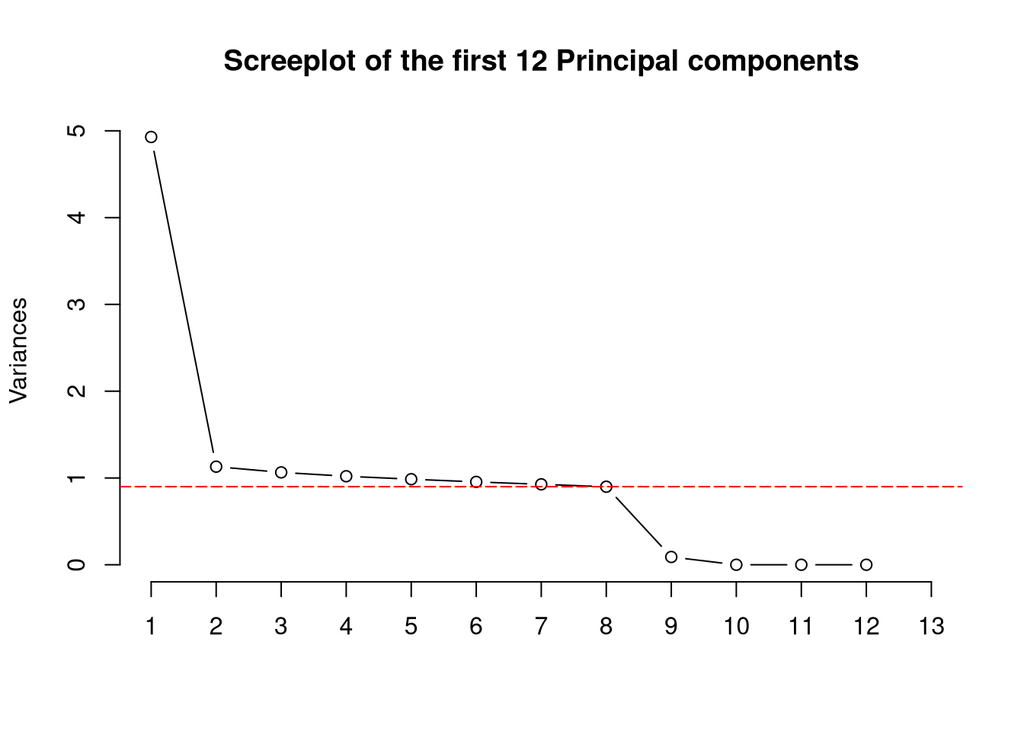

```r
screeplot(results, type = "l", npcs = 13, main = "Screeplot of the first 12 Principal components")
abline(h = 0.9, col="red", lty=5)
```

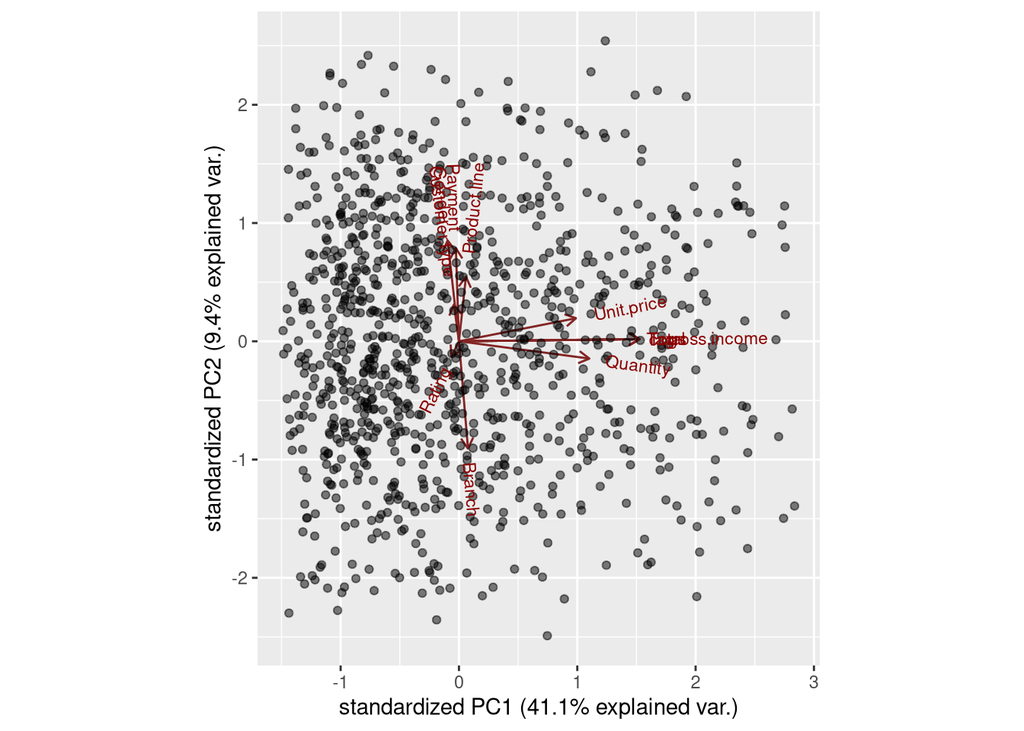

```r
ggbiplot(results,labels.size = 5, alpha = 0.5)
```

Unit price,gross income,tax and quantity contribute to PC1 Payment,gender,Product line and customer type contribute to PC2

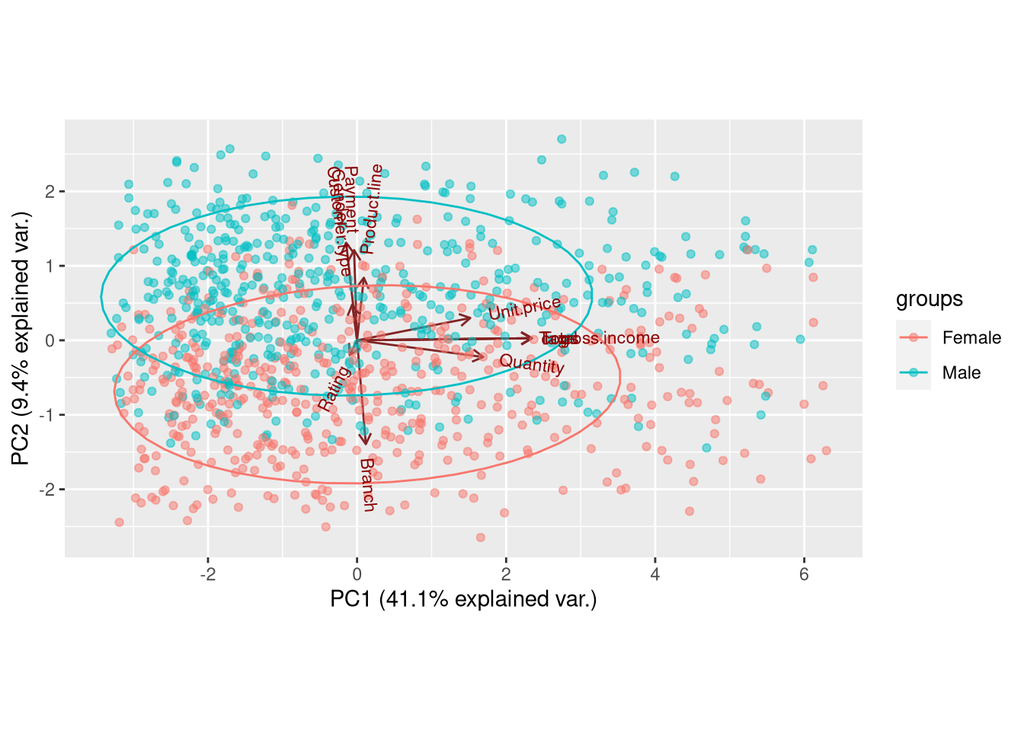

```r
clusters <- function (name,pc1=1,pc2=2){
  cl_list <- factor(sup_market[[name]])
  # species <- cl_list$species
  ggbiplot(results,,choices=c(pc1,pc2),ellipse = TRUE,groups = cl_list, obs.scale = 1, var.scale = 1,labels.size = 5, alpha = 0.5)
}
clusters('Gender')
```

The clusters of the gender show: Males are clustered at the top characterised by all features but the branch, while females are clustered at the bottom with unitprice,tax,gross income,rating and branch influencing their buying.

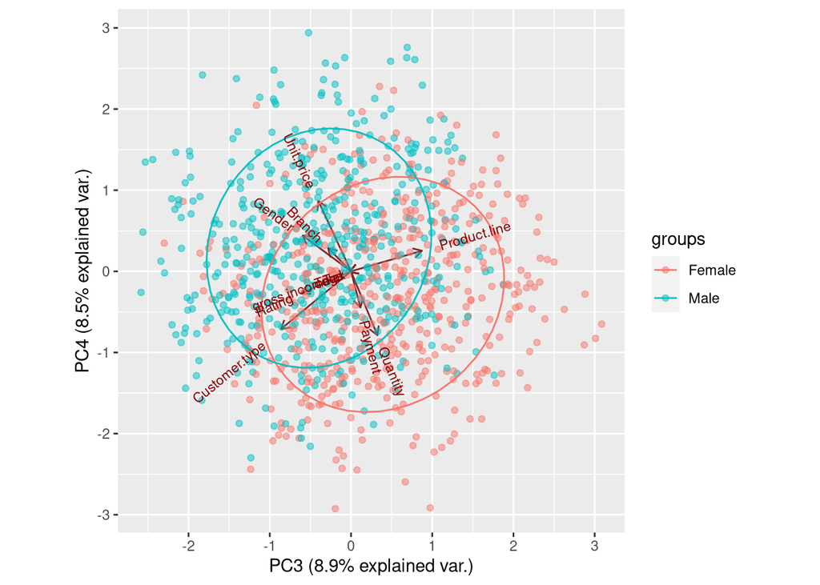

```r
clusters('Gender',3,4)
```

Since the 3rd and 4th princpal components explain lower variances than the first two, i doesnt do that good a job at showing the pattern shown in the previous plot. although it does give a hint on where the different genders lie.

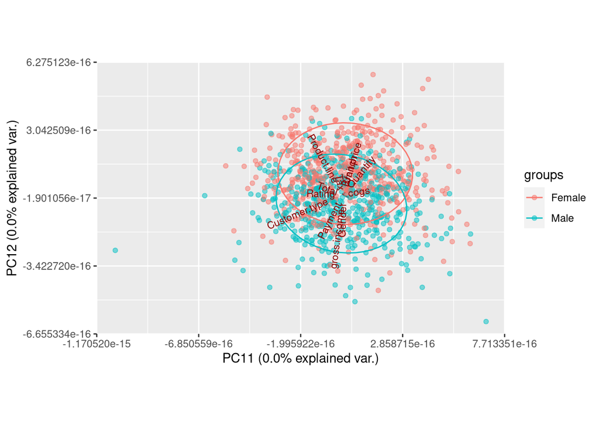

```r
clusters('Gender',11,12)
```

The last 2 principle components perform even worse since they ecplain so little of the variance in the dataset.

# Reducing the attributes using Feature Selection

## Method 1 filter method: high correlation filter

```r
library('caret')
library('corrplot')
```

```r
supermarket_ <- supermarket.org[,-c(10)]
corr_ <- cor(supermarket_)
corr_
```

```
                   Branch Customer.type       Gender Product.line   Unit.price
Branch         1.00000000   -0.01960787 -0.056317558 -0.053937557  0.028202440
Customer.type -0.01960787    1.00000000  0.039996160 -0.036800311 -0.020237875
Gender        -0.05631756    0.03999616  1.000000000  0.005193197  0.015444630
Product.line  -0.05393756   -0.03680031  0.005193197  1.000000000  0.019321028
Unit.price     0.02820244   -0.02023787  0.015444630  0.019321028  1.000000000
Quantity       0.01596379   -0.01676271 -0.074258307  0.020256001  0.010777564
Tax            0.04104666   -0.01967028 -0.049450989  0.031620725  0.633962089
Payment       -0.05010429    0.01807344  0.044577609  0.029896383 -0.015941048
cogs           0.04104666   -0.01967028 -0.049450989  0.031620725  0.633962089
gross.income   0.04104666   -0.01967028 -0.049450989  0.031620725  0.633962089
Rating         0.01023848    0.01888867  0.004800208 -0.020528973 -0.008777507
Total          0.04104666   -0.01967028 -0.049450989  0.031620725  0.633962089
                 Quantity         Tax      Payment        cogs gross.income
Branch         0.01596379  0.04104666 -0.050104288  0.04104666   0.04104666
Customer.type -0.01676271 -0.01967028  0.018073436 -0.01967028  -0.01967028
Gender        -0.07425831 -0.04945099  0.044577609 -0.04945099  -0.04945099
Product.line   0.02025600  0.03162072  0.029896383  0.03162072   0.03162072
Unit.price     0.01077756  0.63396209 -0.015941048  0.63396209   0.63396209
Quantity       1.00000000  0.70551019 -0.003920990  0.70551019   0.70551019
Tax            0.70551019  1.00000000 -0.012433637  1.00000000   1.00000000
Payment       -0.00392099 -0.01243364  1.000000000 -0.01243364  -0.01243364
cogs           0.70551019  1.00000000 -0.012433637  1.00000000   1.00000000
gross.income   0.70551019  1.00000000 -0.012433637  1.00000000   1.00000000
Rating        -0.01581490 -0.03644170 -0.005381289 -0.03644170  -0.03644170
Total          0.70551019  1.00000000 -0.012433637  1.00000000   1.00000000
                    Rating       Total
Branch         0.010238476  0.04104666
Customer.type  0.018888672 -0.01967028
Gender         0.004800208 -0.04945099
Product.line  -0.020528973  0.03162072
Unit.price    -0.008777507  0.63396209
Quantity      -0.015814905  0.70551019
Tax           -0.036441705  1.00000000
Payment       -0.005381289 -0.01243364
cogs          -0.036441705  1.00000000
gross.income  -0.036441705  1.00000000
Rating         1.000000000 -0.03644170
Total         -0.036441705  1.00000000
```

High correlations from tax,gross income ,cogs and total

```r
high_cor <- findCorrelation(corr_, cutoff=0.75)
high_cor
```

```
[1]  9 12  7
```

```r
# Removing the highly correlated features in index (9,12,7)
final <- supermarket_[-high_cor]
```

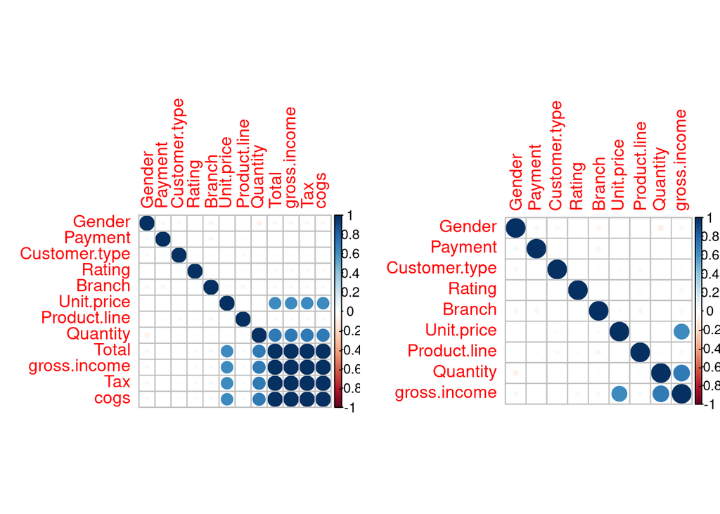

```r
# Plotting the correlations for comparison
par(mfrow = c(1,2))
corrplot(corr_, order = "hclust")
corrplot(cor(final), order = "hclust")
```

Feature selection removes the most correlated features from the dataset in this case were left with 9 features that are not overly correlated

## Method 2 : Wrapper Methods

```r
library('clustvarsel')
library('mclust')
```

```r
# Sequential forward greedy search using the default number of groups
out <- clustvarsel(supermarket_)
out
```

```
------------------------------------------------------
Variable selection for Gaussian model-based clustering
Stepwise (forward/backward) greedy search
------------------------------------------------------

 Variable proposed Type of step   BICclust Model G   BICdiff Decision
          Quantity          Add  -4308.761     E 9  687.4466 Accepted
              cogs          Add -16306.851   VEV 9 1083.0132 Accepted
        Unit.price          Add -21393.079   EVV 7 2812.3733 Accepted
        Unit.price       Remove -16306.851   VEV 9 2812.3733 Rejected
            Rating          Add -25510.859   EVV 7 -184.0917 Rejected
        Unit.price       Remove -16306.851   VEV 9 2812.3733 Rejected

Selected subset: Quantity, cogs, Unit.price
```

```r
final2 <- supermarket_[,out$subset]
head(final2)
```

|  | Quantity | cogs | Unit.price |
| --- | --- | --- | --- |
| 1 | 7 | 522.83 | 74.69 |
| 2 | 5 | 76.40 | 15.28 |
| 3 | 7 | 324.31 | 46.33 |
| 4 | 8 | 465.76 | 58.22 |
| 5 | 7 | 604.17 | 86.31 |
| 6 | 7 | 597.73 | 85.39 |

```r
mod <- Mclust(final2)
summary(mod)
```

```
----------------------------------------------------
Gaussian finite mixture model fitted by EM algorithm
----------------------------------------------------

Mclust EVV (ellipsoidal, equal volume) model with 7 components:

 log-likelihood    n df       BIC       ICL
      -10478.95 1000 63 -21393.08 -21446.89

Clustering table:
  1   2   3   4   5   6   7
173 134 126 148 128 142 149
```

There were achieved 7 clusters in the selected subset of data

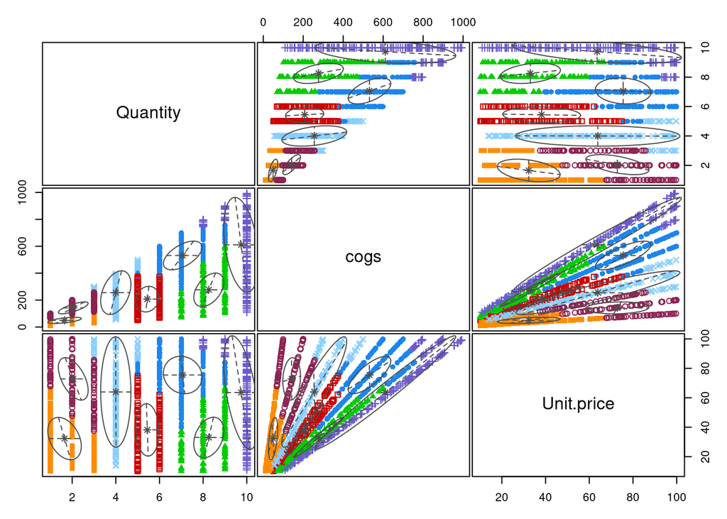

```r
plot(mod,c("classification"))
```

The unsupervised clustering shows 7 clusters from the 3 attributes selected